# Exam 1 - BC

2026-03-04

# 1. Research Question 1:

Which species of bird showed the largest observation changes between the years 2020 and 2021 based on location?

```
## # A tibble: 6 × 3
## # Groups:   loc_id == site_of_interest [1]
##   `loc_id == site_of_interest` american_english_name n_years
##   <lgl>                        <chr>                   <int>
## 1 FALSE                        American Goldfinch          2
## 2 FALSE                        American Robin              2
## 3 FALSE                        Blue Jay                    2
## 4 FALSE                        House Sparrow               2
## 5 FALSE                        Mourning Dove               2
## 6 FALSE                        Northern Cardinal           2
```

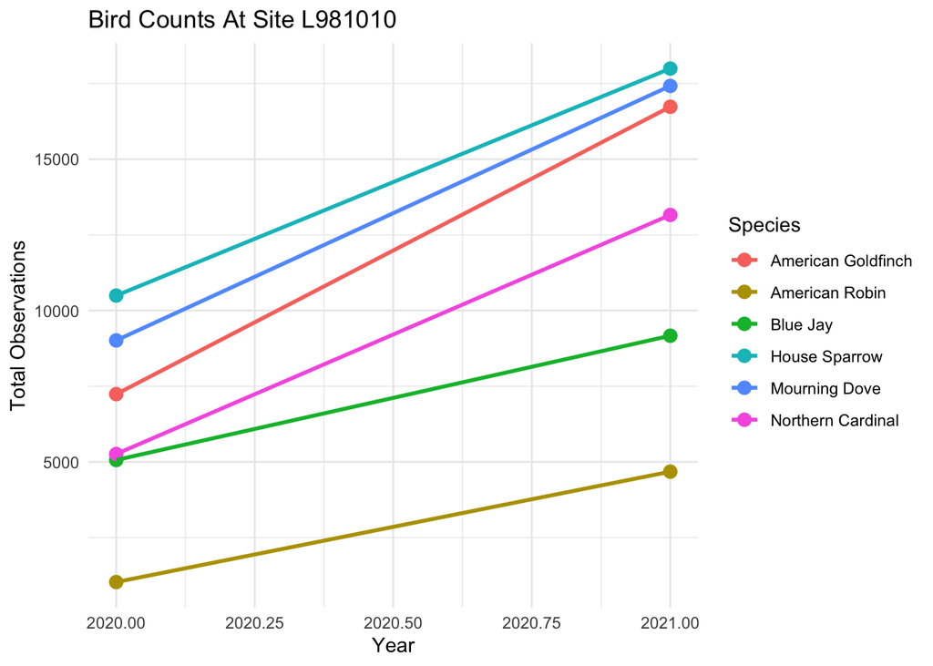

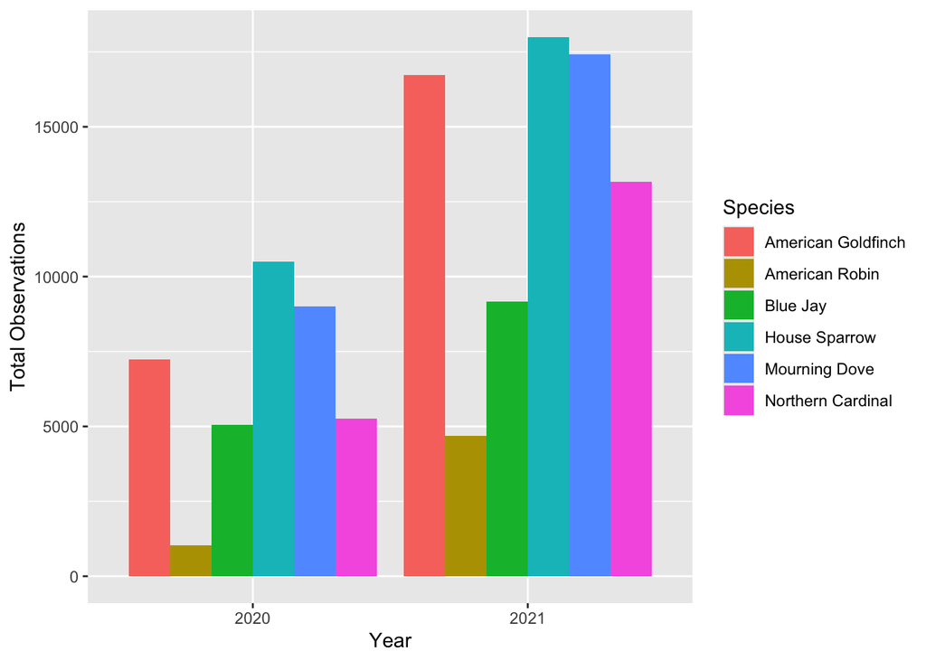

# Research Question 2: How does bird species diversity change across different habitats?

For this question, i used the habitat data along with the bird species data. I calculated the species diversity at each site as well as grouped the habitat types. Then I computed the average of species diversity within each separate habitat as well as used anova. Lastyly, I provided a box plot to show my findings.

```
## # A tibble: 10 × 4
##    habitat          mean_richness sd_richness n_sites
##    <chr>                    <dbl>       <dbl>   <int>
##  1 Agricultural              5.28        3.44      50
##  2 Deciduous Forest          5.80        3.48     754
##  3 Evergreen Forest          4.74        3.27     121
##  4 Freshwater                5.67        5.89       9
##  5 Marsh                     2.33        1.15       3
##  6 Mixed Forest              5.06        3.25     442
##  7 Park                      3.33        3.12       9
##  8 Residential               5.42        3.42   12335
##  9 Swamp                     1          NA          1
## 10 <NA>                      3.87        2.87    1563
```

```
##                Df Sum Sq Mean Sq F value   Pr(>F)
## habitat         8    311   38.89   3.327 0.000829 ***
## Residuals   13715 160320   11.69
## ---
## Signif. codes:  0 '***' 0.001 '**' 0.01 '*' 0.05 '.' 0.1 ' ' 1
## 1563 observations deleted due to missingness
```

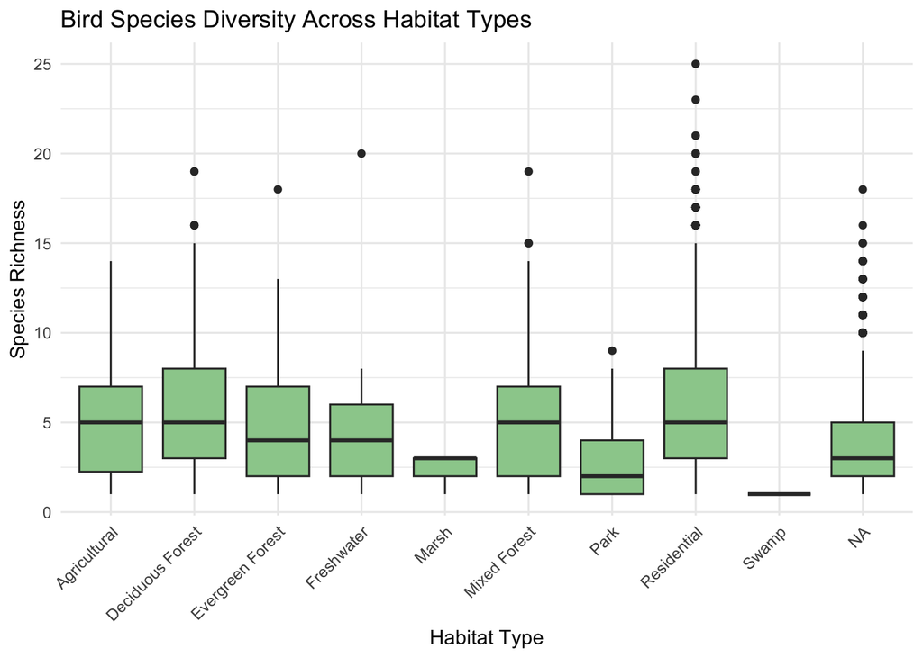

Based on my findings it appears that forest and residential habitats showed higher diversity than habitats such as marshes, swamps, etc. Based on the anova test as well, the p-value was less than 0.05 which means there is strong evidence that supports bird diversity differs depending on habitat type in this dataset.

# Research Question 3: How does the housing density influence the number of birds that were observed?

In order to examine this relationship, I used the combined dataset for my findings. I first filtered out any missing values, then calculated the total number of birds observed at head site using the how_many values. I also grpuped observations based on the housing density column. Lastly, I provided a visual of my findings.

```
## # A tibble: 4 × 4
##   housing_density mean_birds sd_birds n_sites
##             <dbl>      <dbl>    <dbl>   <int>
## 1               1       31.2     37.1    3681
## 2               2       26.3     28.4    3609
## 3               3       21.5     22.0    5474
## 4               4       19.3     23.6    1046
```

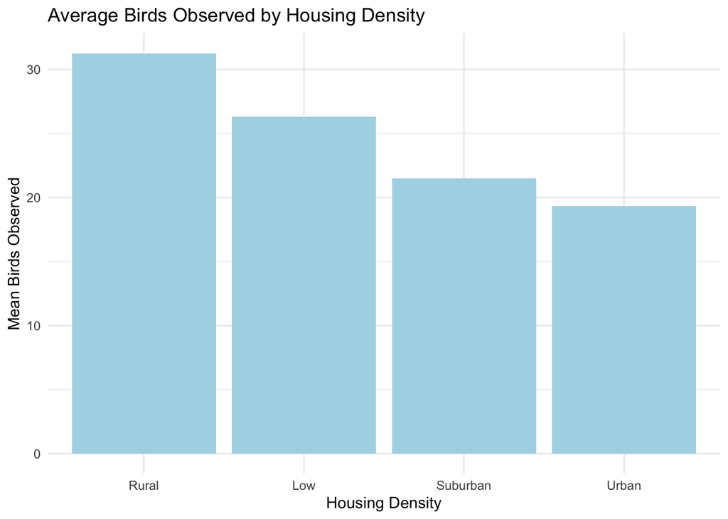

Based on the average birds observed, the Rural section has the highest average while urban has the lowest (low and suburban being in the middle). I believe this makes sense since birds don’t typically flock to cities, except pigeons, the way they do to rural areas. It is interesting in my opinion that suburban sites, based on the table, has the most total sites, yet, it is still second to lowest in mean observations.

# Research Question 4: Does the number and type of feeder influence the number of birds observed at a site?

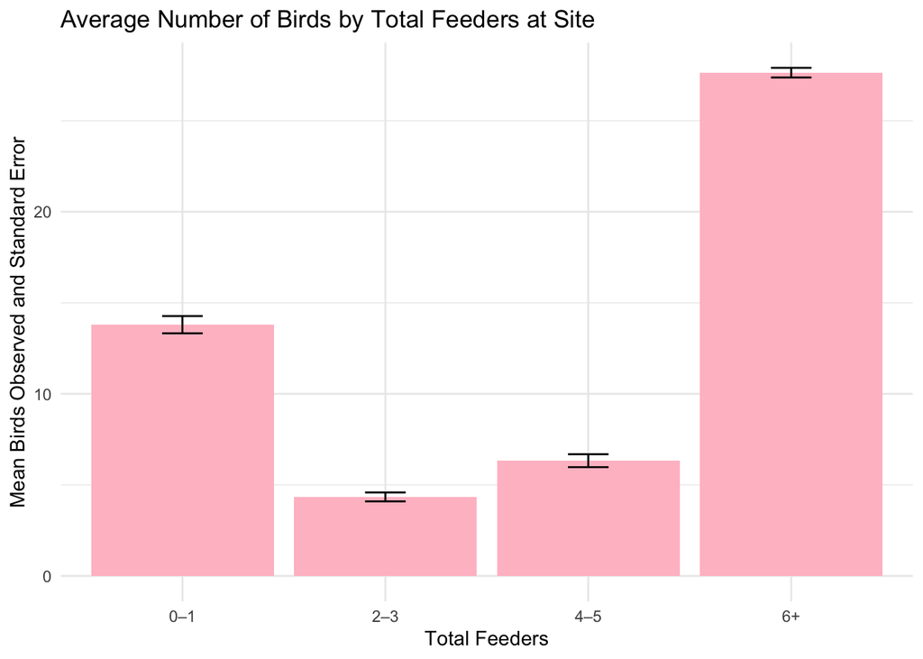

Based on the visuals, the number of total feeders does impact the number of bird observations. Looking at the chart, having 6+ feeders grealy increases the observations compared to 0-5, however, 0-1 seems to have more of an impact than 2-3 and 4-5.